# Regression analysis and diagnostics for Albuquerque housing prices

Author

Steve Simon

Published

August 18, 2024

This program reads data on housing prices in Albuquerque, New Mexico in 1993. Find more information in the [data dictionary](https://github.com/pmean/datasets/blob/master/albuquerque-housing.yaml).

This code is placed in the public domain.

## Load the tidyverse library

For most of your programs, you should load the tidyverse library. The broom package provides a nice way to compute residuals and predicted values. The messages and warnings are suppressed.

```r
library(broom)
library(tidyverse)
```

## Read the data and view a brief summary

Use the read_csv function to read the data. The glimpse function will produce a brief summary.

```r
alb <- read_csv(
  file="../data/albuquerque-housing.csv",
  col_names=TRUE,
  col_types="nnnnccc",
  na=".")
glimpse(alb)
```

```
Rows: 117
Columns: 7
$ price        <dbl> 205000, 208000, 215000, 215000, 199900, 190000, 180000, 1…
$ sqft         <dbl> 2650, 2600, 2664, 2921, 2580, 2580, 2774, 1920, 2150, 171…
$ age          <dbl> 13, NA, 6, 3, 4, 4, 2, 1, NA, 1, 4, 8, 15, 14, 18, NA, 16…
$ features     <dbl> 7, 4, 5, 6, 4, 4, 4, 5, 4, 3, 5, 6, 3, 5, 8, 3, 4, 3, 4, …
$ northeast    <chr> "yes", "yes", "yes", "yes", "yes", "yes", "yes", "yes", "…
$ custom_build <chr> "yes", "yes", "yes", "yes", "yes", "no", "no", "yes", "no…
$ corner_lot   <chr> "no", "no", "no", "no", "no", "no", "no", "no", "no", "no…
```

## m1: regression analysis using sqft to predict price

You might expect that a house with more sqft would have a higher sales price. This code produces some simple descriptive statistics

## m1: Calculate descriptive statistics for number of sqft

```r
alb |>
  summarise(
    sqft_mn=mean(sqft, na.rm=TRUE),
    sqft_sd=sd(sqft, na.rm=TRUE),
    sqft_min=min(sqft, na.rm=TRUE),
    sqft_max=max(sqft, na.rm=TRUE),
    n_missing=sum(is.na(sqft)))
```

```
# A tibble: 1 × 5
  sqft_mn sqft_sd sqft_min sqft_max n_missing
    <dbl>   <dbl>    <dbl>    <dbl>     <int>
1   1654.    524.      837     3750         0
```

## m1: Calculate descriptive statistics for price

```r
alb |>
  summarize(
    price_mn=mean(price, na.rm=TRUE),
    price_sd=sd(price, na.rm=TRUE),
    price_min=min(price, na.rm=TRUE),
    price_max=max(price, na.rm=TRUE),
    n_missing=sum(is.na(price)))
```

```
# A tibble: 1 × 5
  price_mn price_sd price_min price_max n_missing
     <dbl>    <dbl>     <dbl>     <dbl>     <int>
1  106274.   38044.     54000    215000         0
```

## m1: Plot sqft versus price

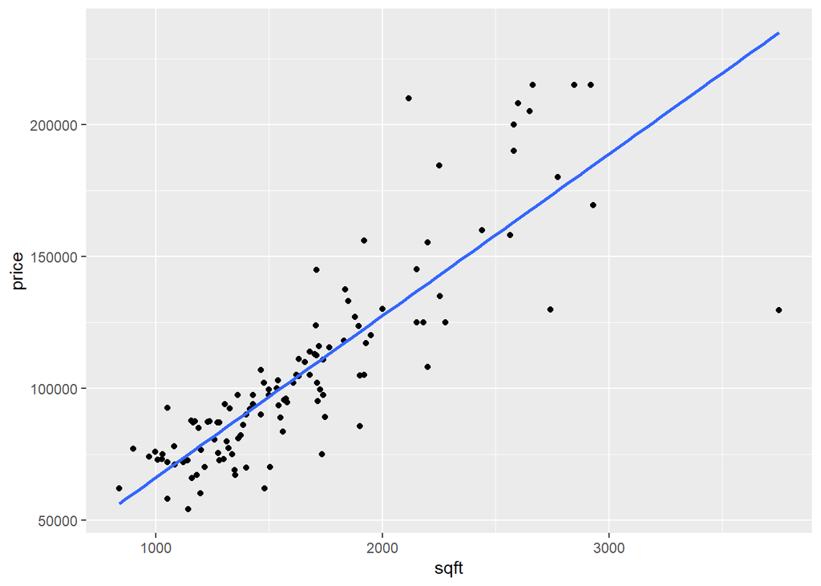

```r
alb |>
  ggplot(aes(sqft, price)) +
    geom_point() +
    geom_smooth(method="lm", se=FALSE)
```

## m1: Use sqft to predict price

```r
m1 <- lm(price~sqft, data=alb)
m1
```

```
Call:
lm(formula = price ~ sqft, data = alb)

Coefficients:
(Intercept)         sqft
    4781.93        61.37
```

Normally, you would follow this up with various functions like anova(), confint(), or tidy(). This program skips those steps to focus on the diagnostic plots of the residuals.

## m1: Calculate residuals and predicted values

```r
r1 <- augment(m1)
glimpse(r1)
```

```
Rows: 117
Columns: 8
$ price      <dbl> 205000, 208000, 215000, 215000, 199900, 190000, 180000, 156…
$ sqft       <dbl> 2650, 2600, 2664, 2921, 2580, 2580, 2774, 1920, 2150, 1710,…
$ .fitted    <dbl> 167403.63, 164335.30, 168262.77, 184034.01, 163107.97, 1631…
$ .resid     <dbl> 37596.3651, 43664.6991, 46737.2315, 30965.9946, 36792.0327,…
$ .hat       <dbl> 0.039734786, 0.036682514, 0.040617583, 0.059012195, 0.03550…
$ .sigma     <dbl> 20217.75, 20107.41, 20042.38, 20315.77, 20232.60, 20373.81,…
$ .cooksd    <dbl> 7.285696e-02, 9.015129e-02, 1.153048e-01, 7.644246e-02, 6.1…
$ .std.resid <dbl> 1.87655228, 2.17598631, 2.33387459, 1.56136142, 1.83237492,…
```

You could have also used the resid() and predict() functions.

## m1: Normal probability plot for residuals

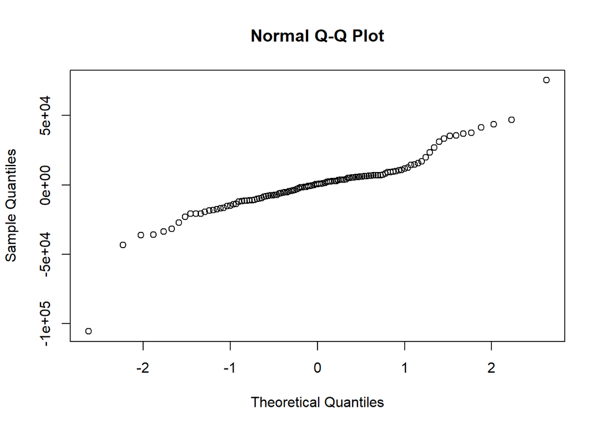

```r
qqnorm(r1$.resid)
```

## m1: Histogram for residuals

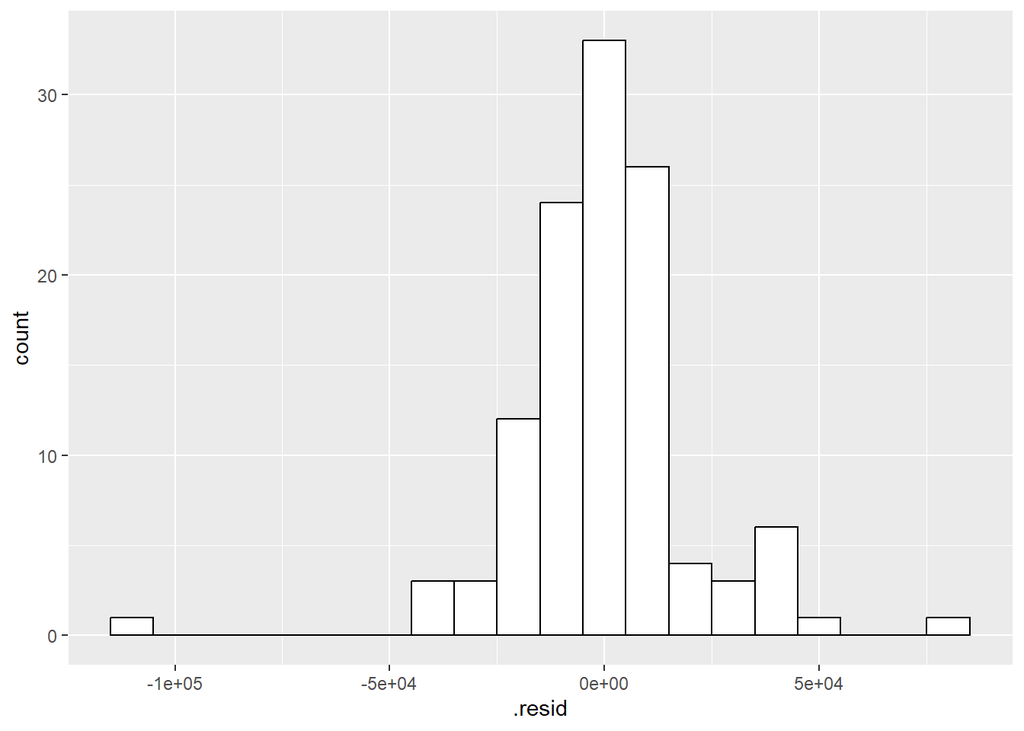

```r
r1 |>
  ggplot(aes(.resid)) +
    geom_histogram(
      binwidth=10000,
      color="black",
      fill="white")
```

## m1: Plot residuals versus sqft

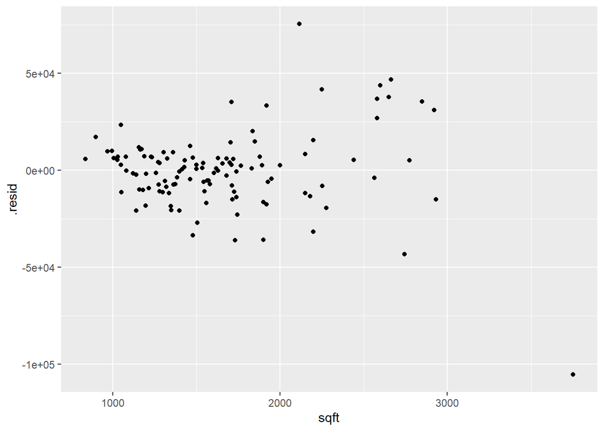

```r
r1 |>
  ggplot(aes(sqft, .resid)) +
    geom_point()
```

## m1: Leverage values

```r
n <- nrow(r1)
r1 |> filter(.hat > 3*2/n)
```

```
# A tibble: 4 × 8
   price  sqft .fitted   .resid   .hat .sigma .cooksd .std.resid
   <dbl> <dbl>   <dbl>    <dbl>  <dbl>  <dbl>   <dbl>      <dbl>
1 215000  2921 184034.   30966. 0.0590 20316.  0.0764      1.56
2 169500  2931 184648.  -15148. 0.0598 20482.  0.0186     -0.764
3 215000  2848 179554.   35446. 0.0534 20249.  0.0895      1.78
4 129500  3750 234907. -105407. 0.147  17535.  2.68       -5.58
```

```r
r1 |>
  filter(abs(.std.resid) > 3)
```

```
# A tibble: 2 × 8
   price  sqft .fitted   .resid   .hat .sigma .cooksd .std.resid
   <dbl> <dbl>   <dbl>    <dbl>  <dbl>  <dbl>   <dbl>      <dbl>
1 129500  3750 234907. -105407. 0.147  17535.   2.68       -5.58
2 210000  2116 134634.   75366. 0.0153 19263.   0.107       3.71
```

## m1: Cook’s distance

```r
r1 |>
  filter(.cooksd > 1)
```

```
# A tibble: 1 × 8
   price  sqft .fitted   .resid  .hat .sigma .cooksd .std.resid
   <dbl> <dbl>   <dbl>    <dbl> <dbl>  <dbl>   <dbl>      <dbl>
1 129500  3750 234907. -105407. 0.147 17535.    2.68      -5.58
```

## m2: scatterplot

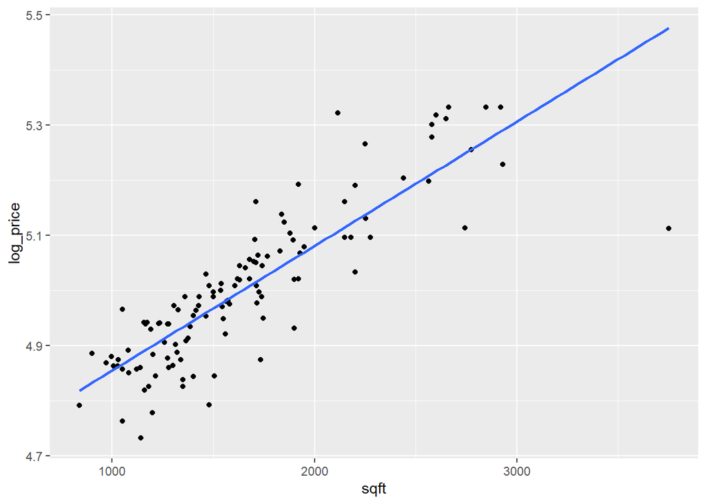

```r
alb$log_price <- log10(alb$price)
alb |>
  ggplot(aes(sqft, log_price)) +
    geom_point() +
    geom_smooth(method="lm", se=FALSE)
```

## m2: linear regression on log transformed price

```r
m2 <- lm(log_price~sqft, data=alb)
m2
```

```
Call:
lm(formula = log_price ~ sqft, data = alb)

Coefficients:
(Intercept)         sqft
  4.6294697    0.0002258
```

## m2: Coefficients back transformed to original scale

```r
10^(coef(m2))
```

```
(Intercept)        sqft
42605.89143     1.00052
```

## m2: Normal probability plot

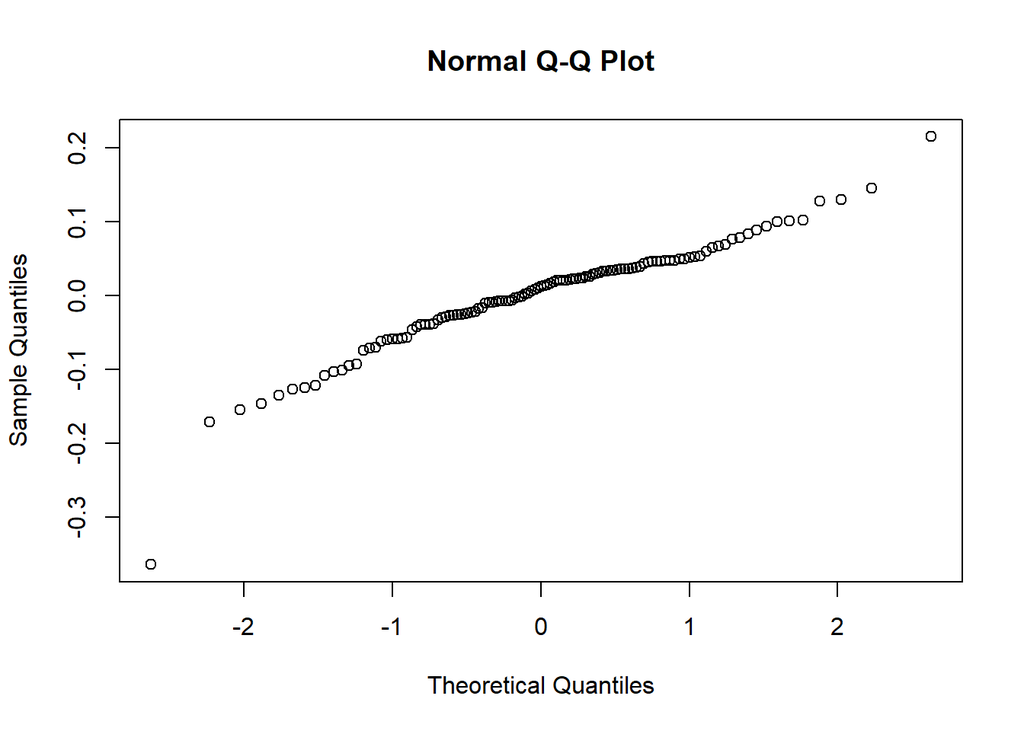

```r
r2 <- augment(m2)
qqnorm(r2$.resid)
```

## m2: Histogram of residuals

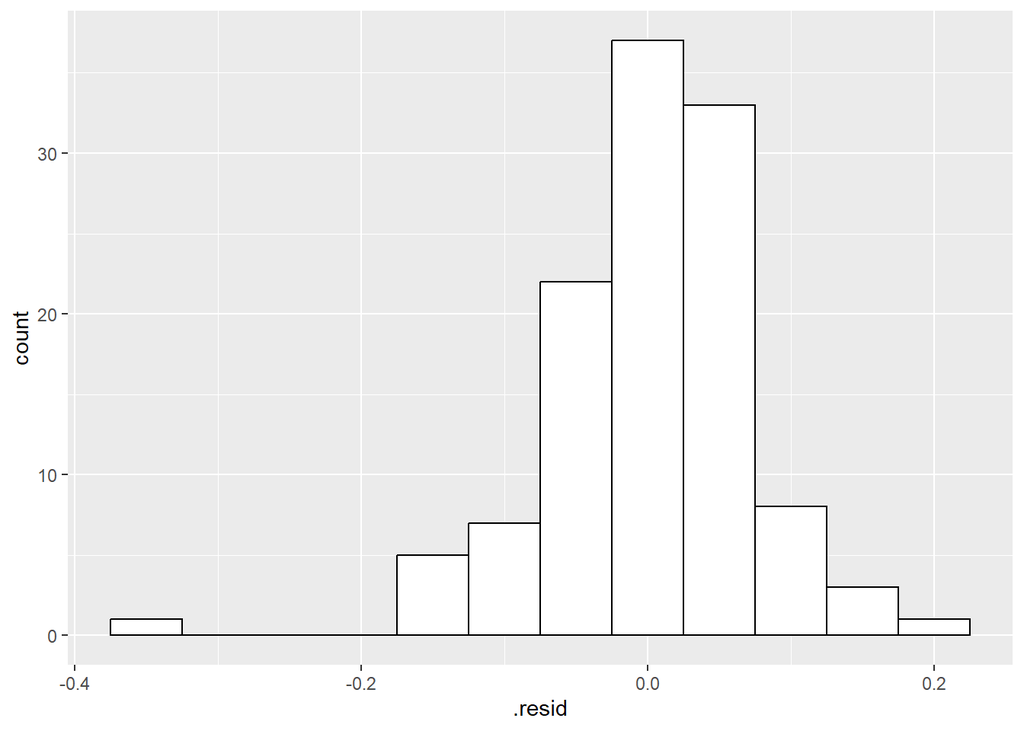

```r
r2 |>
  ggplot(aes(.resid)) +
    geom_histogram(
      binwidth=0.05,
      color="black",
      fill="white")
```

## m2: Plot residuals versus sqft

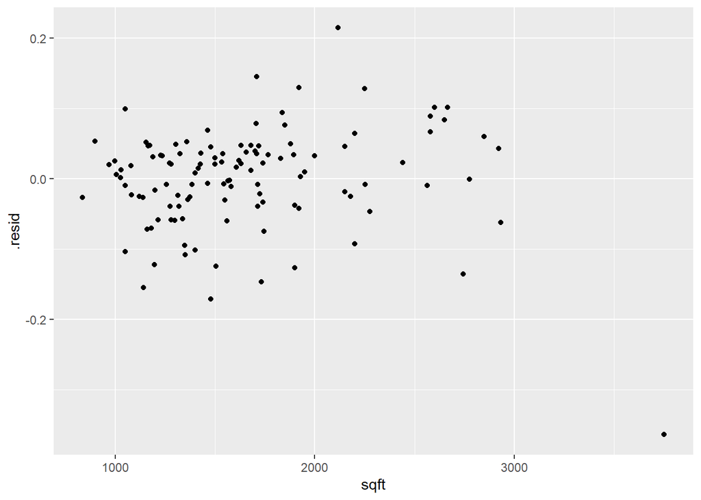

```r
r2 |>
  ggplot(aes(sqft, .resid)) +
    geom_point()
```